# Разработка A/B-тестирования и анализ результатов

Вы работаете продуктовым аналитиком в компании, которая разрабатывает развлекательное приложение с функцией «бесконечной» ленты, как, например, в приложениях с короткими видео. В вашем приложении существует две модели монетизации: первая — ежемесячная платная подписка, которая позволяет пользователям смотреть ленту без рекламы, вторая — демонстрация рекламы для пользователей, которые ещё не оформили подписку.

Команда разработчиков рекомендательных систем создала новый алгоритм рекомендаций, который, по их мнению, будет показывать более интересный контент для каждого пользователя. Вас, как аналитика, просят помочь рассчитать параметры A/B-теста, который позволит проверить эту гипотезу, и проанализировать его результаты.

## Описание данных

У этих таблиц почти совпадает структура и содержание колонок, различаются лишь периоды наблюдения.

Поля таблиц `sessions_project_history.csv`, `sessions_project_test.csv`, `sessions_project_test_part.csv`:

- `user_id` — идентификатор пользователя;
- `session_id` — идентификатор сессии в приложении;
- `session_date` — дата сессии;
- `session_start_ts` — дата и время начала сессии;
- `install_date` — дата установки приложения;
- `session_number` — порядковый номер сессии для конкретного пользователя;
- `registration_flag` — является ли пользователь зарегистрированным;
- `page_counter` — количество просмотренных страниц во время сессии;
- `region` — регион пользователя;
- `device` — тип устройства пользователя;
- `test_group` — тестовая группа (в таблице с историческими данными этого столбца нет).

## Что нужно сделать

Ваши задачи: рассчитать параметры теста, оценить корректность его проведения и проанализировать результаты эксперимента.

### 1. Работа с историческими данными (EDA)

#### 1.1. Загрузка исторических данных

На первом этапе поработайте с историческими данными приложения:

- Импортируйте библиотеку pandas.
- Считайте и сохраните в датафрейм `sessions_history` CSV-файл с историческими данными о сессиях пользователей `sessions_project_history.csv`.

Выведите на экран первые пять строк полученного датафрейма.

```python
#импортируем библиотеки

import pandas as pd
import matplotlib.pyplot as plt
from scipy.stats import ttest_ind
from statsmodels.stats.proportion import proportions_ztest
```

```python
#загружаем датасет
sessions_history = pd.read_csv('https://code.s3.yandex.net/datasets/sessions_project_history.csv')
```

```python
#смотрим первые 5 записей датасета
sessions_history.head()
```

|  | user_id | session_id | session_date | session_start_ts | install_date | session_number | registration_flag | page_counter | region | device |
| --- | --- | --- | --- | --- | --- | --- | --- | --- | --- | --- |
| 0 | E302123B7000BFE4 | F9AF61A0C2023832 | 2025-08-15 | 2025-08-15 17:47:35 | 2025-08-15 | 1 | 0 | 3 | CIS | iPhone |
| 1 | 2530F72E221829FB | 85003A206CBDAC6F | 2025-08-15 | 2025-08-15 16:42:14 | 2025-08-15 | 1 | 0 | 4 | MENA | Android |
| 2 | 876E020A4FC512F5 | 3677423E49D72DEE | 2025-08-15 | 2025-08-15 12:30:00 | 2025-08-15 | 1 | 0 | 4 | EU | PC |
| 3 | 2640B349E1D81584 | 956B45F5915CA225 | 2025-08-15 | 2025-08-15 15:31:31 | 2025-08-15 | 1 | 0 | 4 | CIS | Android |
| 4 | 94E1CBFAEF1F5EE9 | 83BF0DA35F9F1F40 | 2025-08-15 | 2025-08-15 21:33:53 | 2025-08-15 | 1 | 0 | 3 | CIS | Android |

#### 1.2. Знакомство с данными

- Для каждого уникального пользователя `user_id` рассчитайте количество уникальных сессий `session_id`.
- Выведите на экран все данные из таблицы `sessions_history` для одного пользователя с наибольшим количеством сессий. Если таких пользователей несколько, выберите любого из них.
- Изучите таблицу для одного пользователя, чтобы лучше понять логику формирования каждого столбца данных.

```python
#считаем уникальные сессии и находим пользователя с максимальным количеством сессий
unique_sessions = sessions_history.groupby('user_id')['session_id'].nunique().reset_index().sort_values(by='session_id', ascending=False)
print('Количество уникальных сессий для каждого пользователя')
print(unique_sessions)
print('Пользователь с максимальным количеством сессий')
user = str(unique_sessions[unique_sessions['session_id']==unique_sessions['session_id'].max()]['user_id'].head(1).values[0])
user
```

```
Количество уникальных сессий для каждого пользователя
                 user_id  session_id
8948    10E0DEFC1ABDBBE0          10
55627   6A73CB5566BB494D          10
72346   8A60431A825D035B           9
109383  D11541BAC141FB94           9
47956   5BCFE7C4DCC148E9           9
...                  ...         ...
15859   1DF13BB1953B3497           1
51449   628502A3CE7E0A3C           1
15853   1DEEF40DEFBD0C65           1
89905   AC08479B7472C628           1
72184   8A0882B6715D9EE5           1

[134039 rows x 2 columns]
Пользователь с максимальным количеством сессий
```

```
'10E0DEFC1ABDBBE0'
```

```python
#смотрим информацию по сессиям для пользователя с максимальным количеством сессий
sessions_history[sessions_history['user_id']==user]
```

|  | user_id | session_id | session_date | session_start_ts | install_date | session_number | registration_flag | page_counter | region | device |
| --- | --- | --- | --- | --- | --- | --- | --- | --- | --- | --- |
| 115558 | 10E0DEFC1ABDBBE0 | B8F0423BBFFCF5DC | 2025-08-14 | 2025-08-14 13:57:39 | 2025-08-14 | 1 | 0 | 4 | CIS | Android |
| 191751 | 10E0DEFC1ABDBBE0 | 87CA2FA549473837 | 2025-08-15 | 2025-08-15 16:42:10 | 2025-08-14 | 2 | 0 | 3 | CIS | Android |
| 239370 | 10E0DEFC1ABDBBE0 | 4ADD8011DCDCE318 | 2025-08-16 | 2025-08-16 19:53:21 | 2025-08-14 | 3 | 0 | 3 | CIS | Android |
| 274629 | 10E0DEFC1ABDBBE0 | DF0FD0E09BF1F3D7 | 2025-08-17 | 2025-08-17 15:03:43 | 2025-08-14 | 4 | 0 | 1 | CIS | Android |
| 302501 | 10E0DEFC1ABDBBE0 | 3C221774B4DE6885 | 2025-08-18 | 2025-08-18 17:29:14 | 2025-08-14 | 5 | 0 | 4 | CIS | Android |
| 325557 | 10E0DEFC1ABDBBE0 | 031BD7A67048105B | 2025-08-19 | 2025-08-19 13:23:55 | 2025-08-14 | 6 | 0 | 2 | CIS | Android |
| 345336 | 10E0DEFC1ABDBBE0 | FF4315CF4AD4B100 | 2025-08-20 | 2025-08-20 19:31:54 | 2025-08-14 | 7 | 0 | 2 | CIS | Android |
| 377532 | 10E0DEFC1ABDBBE0 | 4045FEA0747203B4 | 2025-08-22 | 2025-08-22 17:54:13 | 2025-08-14 | 8 | 0 | 2 | CIS | Android |
| 403538 | 10E0DEFC1ABDBBE0 | 344B086C421C7F37 | 2025-08-24 | 2025-08-24 14:46:13 | 2025-08-14 | 9 | 0 | 2 | CIS | Android |
| 414743 | 10E0DEFC1ABDBBE0 | 054F20BA371E4C9D | 2025-08-25 | 2025-08-25 18:36:41 | 2025-08-14 | 10 | 0 | 3 | CIS | Android |

Таким образом, максимальное количество сессий - 10. Такое число сессий имеют два пользователя: с ID 10E0DEFC1ABDBBE0 и 6A73CB5566BB494D.

#### 1.3. Анализ числа регистраций

Одна из важнейших метрик продукта — число зарегистрированных пользователей. Используя исторические данные, визуализируйте, как менялось число регистраций в приложении за время его существования.

- Агрегируйте исторические данные и рассчитайте число уникальных пользователей и число зарегистрированных пользователей для каждого дня наблюдения. Для простоты считайте, что у пользователя в течение дня бывает одна сессия максимум и статус регистрации в течение одного дня не может измениться.
- Постройте линейные графики общего числа пользователей и общего числа зарегистрированных пользователей по дням. Отобразите их на одном графике.
- Постройте отдельный линейный график доли зарегистрированных пользователей от всех пользователей по дням.
- На обоих графиках должны быть заголовок, подписанные оси X и Y, сетка и легенда.

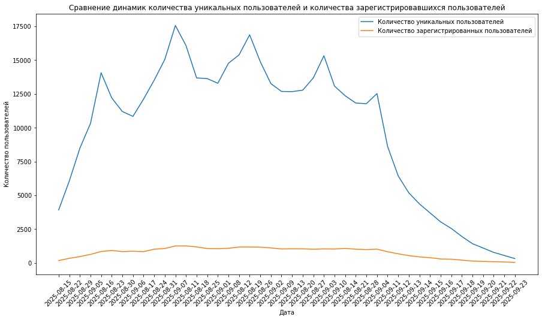

```python
unique_users = sessions_history.groupby('session_date')['user_id'].nunique() #посчитаем количество уникальных пользователей по датам
reg = sessions_history.groupby('session_date')['registration_flag'].sum() #считаем количество зарегистрировавшихся пользователей по датам

#строим линейные графики
plt.figure(figsize=(15, 8))
plt.plot(sessions_history['session_date'].unique(), unique_users, label ='Количество уникальных пользователей')
plt.plot(sessions_history['session_date'].unique(), reg, label ='Количество зарегистрированных пользователей')
plt.xticks(rotation=45)
plt.xlabel("Дата")
plt.ylabel('Количество пользователей')
plt.legend()
plt.title('Сравнение динамик количества уникальных пользователей и количества зарегистрировавшихся пользователей')
plt.show()
```

Теперь построим линейный график доли зарегистрировавшихся пользователей относительно общего количества

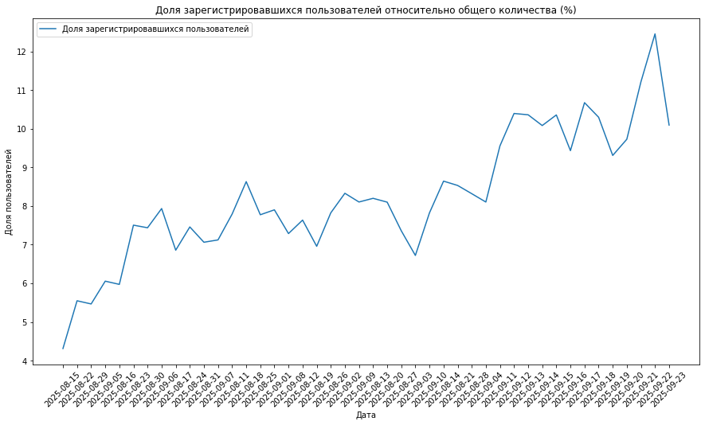

```python
reg_perc = sessions_history.groupby('session_date')['registration_flag'].mean()*100
plt.figure(figsize=(15, 8))
plt.plot(sessions_history['session_date'].unique(), reg_perc, label ='Доля зарегистрировавшихся пользователей')

plt.xticks(rotation=45)
plt.xlabel("Дата")
plt.ylabel('Доля пользователей')
plt.legend()
plt.title('Доля зарегистрировавшихся пользователей относительно общего количества (%)')
plt.show()
```

Видим, что в период до спада в количестве пользователей (до 04.09), доля зарегистрировавшихся не превышала и 10% и держалась на уровне 7-9%.

#### 1.4. Анализ числа просмотренных страниц

Другая важная метрика продукта — число просмотренных страниц в приложении. Чем больше страниц просмотрено, тем сильнее пользователь увлечён контентом, а значит, выше шансы на то, что он зарегистрируется и оплатит подписку.

- Найдите количество сессий для каждого значения количества просмотренных страниц. Например: одну страницу просмотрели в 29160 сессиях, две страницы в 105536 сессиях и так далее.
- Постройте столбчатую диаграмму, где по оси X будет число просмотренных страниц, по оси Y — количество сессий.
- На диаграмме должны быть заголовок, подписанные оси X и Y.

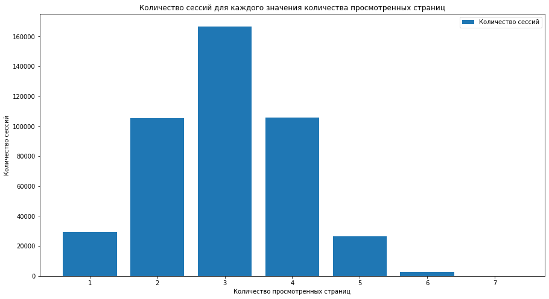

```python
page_sessions = sessions_history.groupby('page_counter')['session_id'].nunique() #считаем для каждого количества просмотренных страниц количество сессий

#строим график
plt.figure(figsize=(15, 8))
plt.bar(sorted(sessions_history['page_counter'].unique()),page_sessions,label ='Количество сессий')

plt.xlabel("Количество просмотренных страниц")
plt.ylabel('Количество сессий')
plt.legend()
plt.title('Количество сессий для каждого значения количества просмотренных страниц')
plt.show()
```

Видим, что больше всего в сессиях просматривают 3 страницы - в более 160 тыс. сессий. А вот 6 и 7 почти не бывает.

#### 1.5. Доля пользователей, просмотревших более четырёх страниц

Продуктовая команда продукта считает, что сессии, в рамках которых пользователь просмотрел 4 и более страниц, говорят об удовлетворённости контентом и алгоритмами рекомендаций. Этот показатель является важной прокси-метрикой для продукта.

- В датафрейме `sessions_history` создайте дополнительный столбец `good_session`. В него войдёт значение `1`, если за одну сессию было просмотрено 4 и более страниц, и значение `0`, если было просмотрено меньше.
- Постройте график со средним значением доли успешных сессий ко всем сессиям по дням за весь период наблюдения.

Сначала создадим новый столбец с хорошими сессиями:

```python
sessions_history['good_session'] = 0
sessions_history.loc[sessions_history.page_counter >= 4, 'good_session'] = 1
sessions_history.head()
```

|  | user_id | session_id | session_date | session_start_ts | install_date | session_number | registration_flag | page_counter | region | device | good_session |
| --- | --- | --- | --- | --- | --- | --- | --- | --- | --- | --- | --- |
| 0 | E302123B7000BFE4 | F9AF61A0C2023832 | 2025-08-15 | 2025-08-15 17:47:35 | 2025-08-15 | 1 | 0 | 3 | CIS | iPhone | 0 |
| 1 | 2530F72E221829FB | 85003A206CBDAC6F | 2025-08-15 | 2025-08-15 16:42:14 | 2025-08-15 | 1 | 0 | 4 | MENA | Android | 1 |
| 2 | 876E020A4FC512F5 | 3677423E49D72DEE | 2025-08-15 | 2025-08-15 12:30:00 | 2025-08-15 | 1 | 0 | 4 | EU | PC | 1 |
| 3 | 2640B349E1D81584 | 956B45F5915CA225 | 2025-08-15 | 2025-08-15 15:31:31 | 2025-08-15 | 1 | 0 | 4 | CIS | Android | 1 |
| 4 | 94E1CBFAEF1F5EE9 | 83BF0DA35F9F1F40 | 2025-08-15 | 2025-08-15 21:33:53 | 2025-08-15 | 1 | 0 | 3 | CIS | Android | 0 |

Теперь построим график среднего значения доли успешных сессий ко всем сессиям

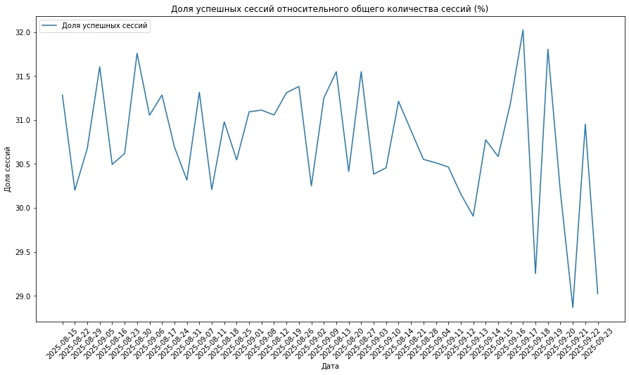

```python
good = sessions_history.groupby('session_date')['good_session'].mean()*100 #считаем долю успешных сессий

#строим график
plt.figure(figsize=(15, 8))
plt.plot(sessions_history['session_date'].unique(), good,label ='Доля успешных сессий')
plt.xticks(rotation=45)
plt.xlabel("Дата")
plt.ylabel('Доля сессий')
plt.legend()
plt.title('Доля успешных сессий относительного общего количества сессий (%)')
plt.show()
```

В основном доля сессий, в которых были просмотрены 4 и более страниц, составляет 30-32%.

### 2. Подготовка к тесту

При планировании теста необходимо проделать несколько важных шагов:

- Определиться с целевой метрикой.
- Рассчитать необходимый размер выборки.
- Исходя из текущих значений трафика, рассчитать необходимую длительность проведения теста.

#### 2.1. Расчёт размера выборки

В рамках курса вам уже приходилось рассчитывать размеры выборки, используя онлайн-калькуляторы. В этом задании предлагаем воспользоваться готовым кодом и рассчитать необходимое для вашего дизайна эксперимента количество пользователей.

Для этого установите в коде ниже следующие параметры:

- Уровень значимости — 0.05.
- Вероятность ошибки второго рода — 0.2.
- Мощность теста.
- Минимальный детектируемый эффект, или MDE, — 3%. Обратите внимание, что здесь нужно указать десятичную дробь, а не процент.

При расчёте размера выборки мы будем использовать метод `solve_power()` из класса `power.NormalIndPower` модуля `statsmodels.stats`.

Запустите ячейку и изучите полученное значение.

```python
from statsmodels.stats.power import NormalIndPower

# Задаём параметры
alpha = 0.05  # Уровень значимости
beta = 0.2  # Ошибка второго рода, часто 1 - мощность
power = 1-beta  # Мощность теста
mde = 0.03  # Минимальный детектируемый эффект

# Инициализируем класс NormalIndPower
power_analysis = NormalIndPower()

# Рассчитываем размер выборки
sample_size = power_analysis.solve_power(
    effect_size = mde,
    power = power,
    alpha = alpha,
    ratio = 1 # Равномерное распределение выборок
)

print(f"Необходимый размер выборки для каждой группы: {int(sample_size)}")
```

```
Необходимый размер выборки для каждой группы: 17441
```

#### 2.1. Расчёт длительности A/B-теста

Используйте данные о количестве пользователей в каждой выборке и среднем количестве пользователей приложения. Рассчитайте длительность теста, разделив одно на другое.

- Рассчитайте среднее количество уникальных пользователей приложения в день.
- Определите длительность теста, исходя из рассчитанного значения размера выборок и среднего дневного трафика приложения. Количество дней округлите в большую сторону.

```python
from math import ceil

# Среднее количество пользователей приложения в день по историческим данным
avg_daily_users = unique_users.mean()

# Рассчитываем длительность теста в днях как отношение размера выборки к среднему числу пользователей
test_duration = ceil(int(sample_size)*2/avg_daily_users)

print(f"Рассчитанная длительность A/B-теста при текущем уровене трафика в {avg_daily_users} пользователей в день составит {test_duration} дней")
```

```
Рассчитанная длительность A/B-теста при текущем уровене трафика в 9907.363636363636 пользователей в день составит 4 дней
```

### 3. Мониторинг А/В-теста

#### 3.1. Проверка распределения пользователей

- Считайте и сохраните в датафрейм `sessions_test_part` CSV-файл с историческими данными о сессиях пользователей `sessions_project_test_part.csv`.
- Рассчитайте количество уникальных пользователей в каждой из экспериментальных групп для одного дня наблюдения.
- Рассчитайте и выведите на экран процентную разницу в количестве пользователей в группах A и B. Постройте любую удобную визуализацию, на которой можно было бы увидеть возможное различие двух групп.

Для расчёта процентной разницы воспользуйтесь формулой: $$P = 100 \cdot \frac{|A − B|}{A}$$

```python
#загружаем новый датасет с ходом теста
sessions_test_part = pd.read_csv('https://code.s3.yandex.net/datasets/sessions_project_test_part.csv')
sessions_test_part.head()
```

|  | user_id | session_id | session_date | session_start_ts | install_date | session_number | registration_flag | page_counter | region | device | test_group |
| --- | --- | --- | --- | --- | --- | --- | --- | --- | --- | --- | --- |
| 0 | 3404844B53442747 | B4901323BD537E45 | 2025-10-14 | 2025-10-14 19:28:49 | 2025-10-14 | 1 | 0 | 3 | CIS | Android | B |
| 1 | 3A2BF4D364E62D89 | 216FC619308F8788 | 2025-10-14 | 2025-10-14 21:11:04 | 2025-10-14 | 1 | 0 | 3 | MENA | iPhone | A |
| 2 | 79CDAE11E32B1597 | EDFCE4AC1A504074 | 2025-10-14 | 2025-10-14 21:44:03 | 2025-10-14 | 1 | 0 | 3 | CIS | iPhone | A |
| 3 | D6AF8D78297A931F | CF0AC0EEDE92C690 | 2025-10-14 | 2025-10-14 19:07:55 | 2025-10-14 | 1 | 0 | 4 | CIS | PC | A |
| 4 | 37E0CE723AE568E0 | 2E6ED45E8C86C4E9 | 2025-10-14 | 2025-10-14 15:39:44 | 2025-10-14 | 1 | 0 | 3 | CIS | Mac | B |

Посчитаем количество уникальных пользователей в каждой группе в первый день эксперимента - 14.10.2025

```python
unique_A = sessions_test_part[(sessions_test_part['session_date']=='2025-10-14') & (sessions_test_part['test_group']=='A')]['user_id'].nunique()
unique_B = sessions_test_part[(sessions_test_part['session_date']=='2025-10-14') & (sessions_test_part['test_group']=='B')]['user_id'].nunique()
print(f'Количество уникальных пользователей в группе А 14.10.2025: {unique_A}')
print(f'Количество уникальных пользователей в группе B 14.10.2025: {unique_B}')
```

```
Количество уникальных пользователей в группе А 14.10.2025: 1477
Количество уникальных пользователей в группе B 14.10.2025: 1466
```

Видим, что количество пользователей в группах не имеет большой разницы.

Теперь посчитаем процентную разницу в количестве пользователей в группах

```python
P = 100 * abs(unique_A - unique_B) / unique_A
print(f'Процентная разница в количестве пользователей в группах A и B: {P}')
```

```
Процентная разница в количестве пользователей в группах A и B: 0.7447528774542993
```

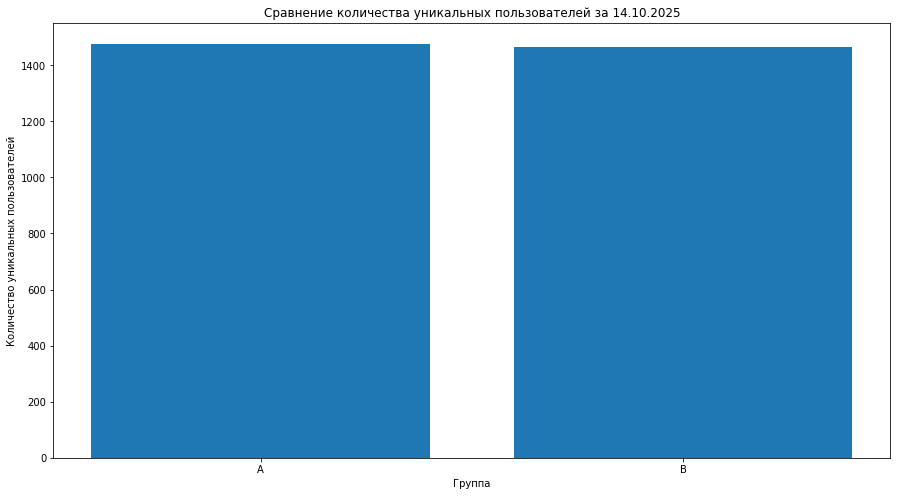

```python
#построим график с количеством пользователей
groups = ['A', 'B']
unique_counts = [unique_A, unique_B]

plt.figure(figsize=(15, 8))
plt.bar(groups, unique_counts)
plt.title(f'Сравнение количества уникальных пользователей за 14.10.2025')
plt.xlabel('Группа')
plt.ylabel('Количество уникальных пользователей')
plt.show()
```

Таким образом, процентная разница меньше 1% и на столбчатой диаграмме количество пользователей в группах также почти одинаково. Значит пользователи равномерно распределены по группам.

#### 3.2. Проверка пересечений пользователей

Помимо проверки равенства количества пользователей в группах полезно убедиться в том, что группы независимы. Для этого нужно убедиться, что никто из пользователей случайно не попал в обе группы одновременно.

- Рассчитайте количество пользователей, которые встречаются одновременно в группах A и B, или убедитесь, что таких нет.

```python
#найдем пересечения в группах
A = sessions_test_part[sessions_test_part['test_group'] == 'A']['user_id']
B = sessions_test_part[sessions_test_part['test_group'] == 'B']['user_id']

intersection = list(set(A) & set(B))
print(intersection)
```

```
[]
```

Получили пустой список с пересениями, значит их нет и данные независимы.

#### 3.3. Равномерность разделения пользователей по устройствам

Полезно также убедиться в том, что пользователи равномерно распределены по всем доступным категориальным переменным — типам устройства и регионам.

Постройте две диаграммы:

- доля каждого типа устройства для пользователей из группы A,
- доля каждого типа устройства для пользователей из группы B.

Постарайтесь добавить на диаграммы все необходимые подписи, пояснения и заголовки, которые позволят сделать вывод о том, совпадает ли распределение устройств в группах A и B.

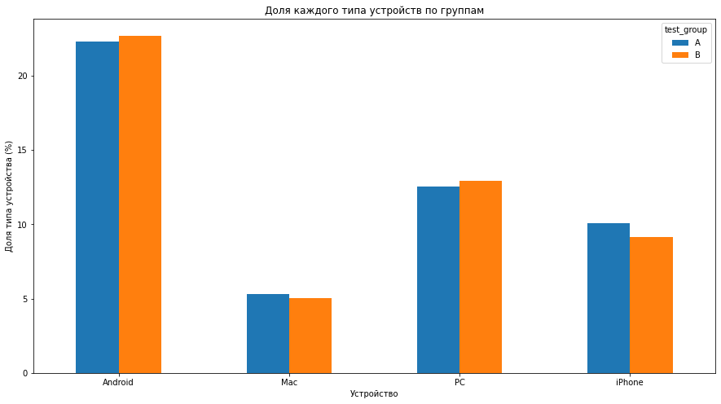

```python
#считаем долю каждого типа устройства для уникальных пользователей из групп
devices = sessions_test_part.groupby(['device', 'test_group'])['user_id'].nunique()/sessions_test_part['user_id'].nunique()*100

devices.unstack(fill_value=0).plot(kind='bar', title="Доля каждого типа устройств по группам", xlabel='Устройство', ylabel='Доля типа устройства (%)', figsize=(15,8), legend='Группа', rot=0)
plt.show()
```

Видим, что пользователи также равномерно распределены и по типам устройств, нигде нет явного перевеса.

#### 3.4. Равномерность распределения пользователей по регионам

Теперь убедитесь, что пользователи равномерно распределены по регионам.

Постройте две диаграммы:

- доля каждого региона для пользователей из группы A,
- доля каждого региона для пользователей из группы B.

Постарайтесь добавить на диаграммы все необходимые подписи, пояснения и заголовки, которые позволят сделать вывод о том, совпадает ли распределение регионов в группах A и B. Постарайтесь использовать другой тип диаграммы, не тот, что в прошлом задании.

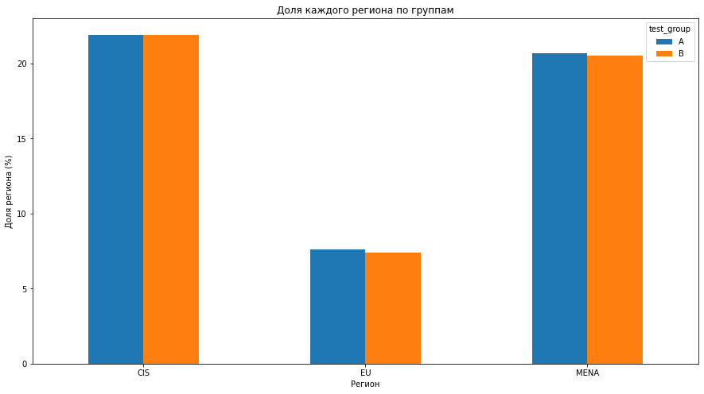

```python
# считаем долю регионов уникальных пользователей из групп
regions = sessions_test_part.groupby(['region', 'test_group'])['user_id'].nunique()/sessions_test_part['user_id'].nunique()*100

regions.unstack(fill_value=0).plot(kind='bar', title="Доля каждого региона по группам", xlabel='Регион', ylabel='Доля региона (%)', figsize=(15,8), legend='Группа', rot=0)
plt.show()
```

По регионам пользователи распределены также равномерно.

#### 3.5. Вывод после проверки A/B-теста

На основе проведённого анализа A/B-теста сформулируйте и запишите свои выводы. В выводе обязательно укажите:

- Были ли обнаружено различие в количестве пользователей в двух группах.
- Являются ли выборки независимыми. Было ли обнаружено пересечение пользователей из тестовой и контрольной групп.
- Сохраняется ли равномерное распределение пользователей тестовой и контрольной групп по категориальным переменным: устройствам и регионам.

Сделайте заключение о том, корректно ли проходит A/B-тест или наблюдаются какие-либо нарушения.

По результатам анализа хода A/B теста можно сделать следующие выводы:

- различие в количестве пользователей в группах составляет меньше 1%, что говорит о том, что они распределены равномерно;
- также, пользователи равномерно распределены по типам устройств и регионам, что подтверждают построенные столбчатые диаграммы;
- выборки являются независимыми, имеется 0 пересечений в идентификаторах пользователей.

Таким образом, тест проходит без нарушений.

### 4. Проверка результатов A/B-теста

A/B-тест завершён, и у вас есть результаты за все дни проведения эксперимента. Необходимо убедиться в корректности теста и верно интерпретировать результаты.

#### 4.1. Получение результатов теста и подсчёт основной метрики

- Считайте и сохраните в датафрейм `sessions_test` CSV-файл с историческими данными о сессиях пользователей `sessions_project_test.csv`.
- В датафрейме `sessions_test` создайте дополнительный столбец `good_session`. В него войдёт значение `1`, если за одну сессию было просмотрено 4 и более страниц, и значение `0`, если просмотрено меньше.

```python
# загружаем новый датасет с данными за весь период теста
sessions_test = pd.read_csv('https://code.s3.yandex.net/datasets/sessions_project_test.csv')
sessions_test.head()
```

|  | user_id | session_id | session_date | session_start_ts | install_date | session_number | registration_flag | page_counter | region | device | test_group |
| --- | --- | --- | --- | --- | --- | --- | --- | --- | --- | --- | --- |
| 0 | 6DAE3B3654DA738E | C69249E26E58F6E2 | 2025-10-26 | 2025-10-26 18:15:05 | 2025-10-16 | 3 | 0 | 3 | MENA | Android | A |
| 1 | 0A3FE5D1DD59110A | 66D66D7C9F5181B7 | 2025-10-21 | 2025-10-21 17:04:53 | 2025-10-15 | 2 | 1 | 2 | CIS | Android | B |
| 2 | 2041F1D7AA740B88 | 50DE51D42215E74C | 2025-10-23 | 2025-10-23 17:39:29 | 2025-10-19 | 3 | 0 | 2 | MENA | Android | A |
| 3 | 43D7585009168086 | 5763C0C353C22263 | 2025-10-24 | 2025-10-24 15:01:57 | 2025-10-18 | 4 | 0 | 1 | CIS | iPhone | B |
| 4 | 15AD68B14D62D88C | B1AD09F93C1053BC | 2025-10-17 | 2025-10-17 17:34:39 | 2025-10-17 | 1 | 0 | 2 | MENA | Android | B |

```python
# создаем новый столбец с хорошими сессиями
sessions_test['good_session'] = 0
sessions_test.loc[sessions_test.page_counter >= 4, 'good_session'] = 1
sessions_test.head(8)
```

|  | user_id | session_id | session_date | session_start_ts | install_date | session_number | registration_flag | page_counter | region | device | test_group | good_session |
| --- | --- | --- | --- | --- | --- | --- | --- | --- | --- | --- | --- | --- |
| 0 | 6DAE3B3654DA738E | C69249E26E58F6E2 | 2025-10-26 | 2025-10-26 18:15:05 | 2025-10-16 | 3 | 0 | 3 | MENA | Android | A | 0 |
| 1 | 0A3FE5D1DD59110A | 66D66D7C9F5181B7 | 2025-10-21 | 2025-10-21 17:04:53 | 2025-10-15 | 2 | 1 | 2 | CIS | Android | B | 0 |
| 2 | 2041F1D7AA740B88 | 50DE51D42215E74C | 2025-10-23 | 2025-10-23 17:39:29 | 2025-10-19 | 3 | 0 | 2 | MENA | Android | A | 0 |
| 3 | 43D7585009168086 | 5763C0C353C22263 | 2025-10-24 | 2025-10-24 15:01:57 | 2025-10-18 | 4 | 0 | 1 | CIS | iPhone | B | 0 |
| 4 | 15AD68B14D62D88C | B1AD09F93C1053BC | 2025-10-17 | 2025-10-17 17:34:39 | 2025-10-17 | 1 | 0 | 2 | MENA | Android | B | 0 |
| 5 | 31F7A42B32103403 | E9B64B779C3348ED | 2025-10-20 | 2025-10-20 17:09:41 | 2025-10-19 | 2 | 0 | 2 | CIS | PC | B | 0 |
| 6 | 87C09E3E3B334959 | FECFF83C13DC9364 | 2025-10-22 | 2025-10-22 23:51:42 | 2025-10-20 | 3 | 0 | 4 | CIS | iPhone | B | 1 |
| 7 | 457F2674E87EF6E7 | 14F71C18BE2CEC08 | 2025-10-19 | 2025-10-19 11:49:11 | 2025-10-19 | 1 | 0 | 3 | MENA | Mac | A | 0 |

#### 4.2. Проверка корректности результатов теста

Прежде чем приступать к анализу ключевых продуктовых метрик, необходимо убедиться, что тест проведён корректно и вы будете сравнивать две сопоставимые группы.

- Рассчитайте количество уникальных сессий для каждого дня и обеих тестовых групп, используя группировку.
- Проверьте, что количество уникальных дневных сессий в двух выборках не различается или различия не статистически значимы. Используйте статистический тест, который позволит сделать вывод о равенстве средних двух выборок.
- В качестве ответа выведите на экран полученное значение p-value и интерпретируйте его.

Сначала посчитаем для каждой группы количество уникальных сессий по дням

```python
# считаем уникальные сессии для группы А
un_sessions_A = sessions_test[sessions_test['test_group']=='A'].groupby('session_date')['session_id'].nunique()
un_sessions_A
```

```
session_date
2025-10-14    1502
2025-10-15    2235
2025-10-16    3280
2025-10-17    4089
2025-10-18    5013
2025-10-19    6535
2025-10-20    5837
2025-10-21    3927
2025-10-22    3083
2025-10-23    2470
2025-10-24    2090
2025-10-25    1897
2025-10-26    1669
2025-10-27    1454
2025-10-28    1279
2025-10-29    1068
2025-10-30     887
2025-10-31     644
2025-11-01     434
2025-11-02     158
Name: session_id, dtype: int64
```

```python
# считаем уникальные сессии для группы Б
un_sessions_B = sessions_test[sessions_test['test_group']=='B'].groupby('session_date')['session_id'].nunique()
un_sessions_B
```

```
session_date
2025-10-14    1628
2025-10-15    2283
2025-10-16    3241
2025-10-17    4054
2025-10-18    5059
2025-10-19    6779
2025-10-20    6089
2025-10-21    3981
2025-10-22    3111
2025-10-23    2548
2025-10-24    2068
2025-10-25    1814
2025-10-26    1692
2025-10-27    1517
2025-10-28    1289
2025-10-29    1131
2025-10-30     876
2025-10-31     669
2025-11-01     465
2025-11-02     160
Name: session_id, dtype: int64
```

Теперь, чтобы проверить, что количество уникальных сессий за день не различается между группами или различается не сильно, проведем t-тест, чтобы сравнить средние значения выборок. То есть нулевая гипотеза: средние значения выборок для групп A и B равны. Альтернатива: средние значения не равны. Уровень значимости выберем 0.05

```python
T_test_result = ttest_ind(un_sessions_A, un_sessions_B, alternative='two-sided')

alpha=0.05
if T_test_result.pvalue<alpha:
    print(f'Нулевая гипотеза отвергается, pvalue={T_test_result.pvalue}')
else:
    print(f'Не можем отвергнуть нулевую гипотезу, pvalue={T_test_result.pvalue}')
```

```
Не можем отвергнуть нулевую гипотезу, pvalue=0.938219304859116
```

Проведенный статистический тест говорит о том, что нулевую гипотезу о том, что средние значения выборок для обеих групп равны, мы не можем отвергнуть, так как значение pvalue больше уровня значимости. Значит различия незначительны и группы сопоставимы.

#### 4.3. Сравнение доли успешных сессий

Когда вы убедились, что количество сессий в обеих выборках не различалось, можно переходить к анализу ключевой метрики — доли успешных сессий.

Используйте созданный на первом шаге задания столбец `good_session` и рассчитайте долю успешных сессий для выборок A и B, а также разницу в этом показателе. Полученный вывод отобразите на экране.

```python
good_sessions_A = sessions_test[sessions_test['test_group']=='A']['good_session'].mean()*100
good_sessions_B = sessions_test[sessions_test['test_group']=='B']['good_session'].mean()*100
dif = good_sessions_A-good_sessions_B
print(f'Доля успешных сессий в группе А: {good_sessions_A} %')
print(f'Доля успешных сессий в группе Б: {good_sessions_B} %')
print(f'Разница в доле успешных сессий: {dif} %')
```

```
Доля успешных сессий в группе А: 30.772335573449578 %
Доля успешных сессий в группе Б: 31.828992745867524 %
Разница в доле успешных сессий: -1.056657172417946 %
```

#### 4.4. Насколько статистически значимо изменение ключевой метрики

На предыдущем шаге вы убедились, что количество успешных сессий в тестовой выборке примерно на 1.1% выше, чем в контрольной, но делать выводы только на основе этого значения будет некорректно. Для принятия решения всегда необходимо отвечать на вопрос: является ли это изменение статистически значимым.

- Используя статистический тест, рассчитайте, является ли изменение в метрике доли успешных сессий статистически значимым.
- Выведите на экран полученное значение p-value и свои выводы о статистической значимости. Напомним, что уровень значимости в эксперименте был выбран на уровне 0.05.

Проведем статистический Z-тест пропорций, который позволит понять, существует ли значимая разница между долями в двух выборках. Гипотеза H_0: доля успешных сессий в группе А равна доле успешных сессий в группе Б. Гипотеза H_1: доля успешных сессий в группе А меньше, чем доля успешных сессий в группе Б.

```python
alpha = 0.05

#считаем размер каждой группы
n_a, n_b = sessions_test[sessions_test['test_group']=='A'].shape[0], sessions_test[sessions_test['test_group']=='B'].shape[0]
#считаем количество успехов в каждой группе
m_a = sessions_test[(sessions_test['test_group']=='A') & (sessions_test['good_session']==1)].shape[0]
m_b = sessions_test[(sessions_test['test_group']=='B') & (sessions_test['good_session']==1)].shape[0]
```

```python
# проводим тест

stats_ztest, pvalue_ztest = proportions_ztest([m_a, m_b], [n_a, n_b], alternative='smaller')
if pvalue_ztest<alpha:
    print(f'Нулевая гипотеза отвергается, pvalue={pvalue_ztest}')
else:
    print(f'Не можем отвергнуть нулевую гипотезу, pvalue={pvalue_ztest}')
```

```
Нулевая гипотеза отвергается, pvalue=0.0001574739988036123
```

Таким образом, гипотеза о том, что доля успешных сессий не изменилась, отвергается. То есть изменение в доле в 1,1% является статистически значимым.

#### 4.5. Вывод по результатам A/B-эксперимента

На основе проведённого анализа результатов теста сформулируйте и запишите свои выводы для команды разработки приложения. В выводе обязательно укажите:

- Характеристики проведённого эксперимента, количество задействованных пользователей и длительность эксперимента.
- Повлияло ли внедрение нового алгоритма рекомендаций на рост ключевой метрики и как.
- Каким получилось значение p-value для оценки статистической значимости выявленного эффекта.
- Стоит ли внедрять новоовведение в приложение.

```python
sessions_test['user_id'].nunique()
```

```
30579
```

```python
sessions_test['session_date'].nunique()
```

```
20
```

Выводы:

- Разработчики приложения хотели понять, поможет ли новая система рекомендаций повысить долю сессий, в течение которых просмотрели 4 и более страницы. В ходе данного эксперимента было задействовано 30579 пользователей, длился он 20 дней.
- Новый алгоритм помог увеличить эту метрику на 1,1%.
- Проведенный Z-тест пропорций показал, что такое увеличение является статистически значимым, pvalue=0.00016 при уровне значимости в 0.05.
- Исходя из результатов, можно сказать, что данное нововведение можно внедрить.